# Final_21500268, Park Seongchan

Park Seongchan

2020 6 16

# Load Data

```r
load('final_test.RData')
sum(is.na(housing_train))
```

```
## [1] 0
```

```r
sum(is.na(housing_test))
```

```
## [1] 0
```

```r
sum(is.na(shopping_train))
```

```
## [1] 0
```

```r
sum(is.na(shopping_test))
```

```
## [1] 0
```

데이터를 load 하고, 각 데이터프레임에 NA 값이 있는지 먼저 확인합니다.

```r
housing_train$X1 <-
  ifelse(housing_train$X1 == 2012.667, '2012 8month',
    ifelse(housing_train$X1 == 2012.750, '2012 9month',
      ifelse(housing_train$X1 == 2012.833, '2012 10month',
        ifelse(housing_train$X1 == 2012.917, '2012 11month',
          ifelse(housing_train$X1 == 2013.000, '2012 12month',
            ifelse(housing_train$X1 == 2013.083, '2013 1month',
              ifelse(housing_train$X1 == 2013.167, '2013 2month',
                ifelse(housing_train$X1 == 2013.250, '2013 3month',
                  ifelse(housing_train$X1 == 2013.333, '2013 4month',
                    ifelse(housing_train$X1 == 2013.417, '2013 5month',
                      ifelse(housing_train$X1 == 2013.500, '2013 6month', '2013 7month')))))))))))

housing_train <- separate(housing_train, X1, c('year', 'month'), sep = ' ')
colnames(housing_train)[3:8] <- c('age', 'distance_MRT',
                                  'number_store', 'latitude', 'degree', 'price')
head(housing_train, 5)
```

```
##   year   month  age distance_MRT number_store latitude   degree price
## 1 2012 10month 34.7     482.7581            5 24.97433 121.5386  41.1
## 2 2012  9month 16.0    4066.5870            0 24.94297 121.5034  11.6
## 3 2012  8month  1.1     329.9747            5 24.98254 121.5439  51.8
## 4 2012 12month 22.8     707.9067            2 24.98100 121.5471  36.6
## 5 2012 10month 31.7    1160.6320            0 24.94968 121.5301  13.7
```

그 후에는 모델을 만들기 위해 train data의 전처리를 수행합니다.

가장 먼저 year와 month으로 이루어져 있는 X1 변수를 전처리 하기 위해 ifelse 함수를 사용하여 연도와 월으로 바꿔줍니다.

그리고 나서는 tidyr package의 separate 함수를 사용하여 가운데 공백을 기준으로 year와 month로 나눠줍니다.

또한 각 변수들의 이름을 직관적으로 이해할 수 있게 수정합니다.

```r
housing_test$X1 <-
  ifelse(housing_test$X1 == 2012.667, '2012 8month',
    ifelse(housing_test$X1 == 2012.750, '2012 9month',
      ifelse(housing_test$X1 == 2012.833, '2012 10month',
        ifelse(housing_test$X1 == 2012.917, '2012 11month',
          ifelse(housing_test$X1 == 2013.000, '2012 12month',
            ifelse(housing_test$X1 == 2013.083, '2013 1month',
              ifelse(housing_test$X1 == 2013.167, '2013 2month',
                ifelse(housing_test$X1 == 2013.250, '2013 3month',
                  ifelse(housing_test$X1 == 2013.333, '2013 4month',
                    ifelse(housing_test$X1 == 2013.417, '2013 5month',
                      ifelse(housing_test$X1 == 2013.500, '2013 6month', '2013 7month')))))))))))

housing_test <- separate(housing_test, X1, c('year', 'month'), sep = ' ')
colnames(housing_test)[3:7] <- c('age', 'distance_MRT',
                                 'number_store', 'latitude', 'degree')
```

동일한 전처리 과정을 test data에도 적용해줍니다.

```r
str(housing_train)
```

```
## 'data.frame':    314 obs. of  8 variables:
##  $ year        : chr  "2012" "2012" "2012" "2012" ...
##  $ month       : chr  "10month" "9month" "8month" "12month" ...
##  $ age         : num  34.7 16 1.1 22.8 31.7 10.4 32.1 15.5 19.5 31.7 ...
##  $ distance_MRT: num  483 4067 330 708 1161 ...
##  $ number_store: int  5 0 5 2 0 5 3 4 9 0 ...
##  $ latitude    : num  25 24.9 25 25 24.9 ...
##  $ degree      : num  122 122 122 122 122 ...
##  $ price       : num  41.1 11.6 51.8 36.6 13.7 33.6 27 37.4 42.2 13.8 ...
```

```r
housing_train[,c(1, 2)] <- lapply(housing_train[,c(1, 2)], as.factor)
housing_test[,c(1, 2)] <- lapply(housing_test[,c(1, 2)], as.factor)
```

그 후에는 변수들의 type을 확인하고, 분류형의 의미가 있는 year와 month는 factor형으로 변환시켜줍니다.

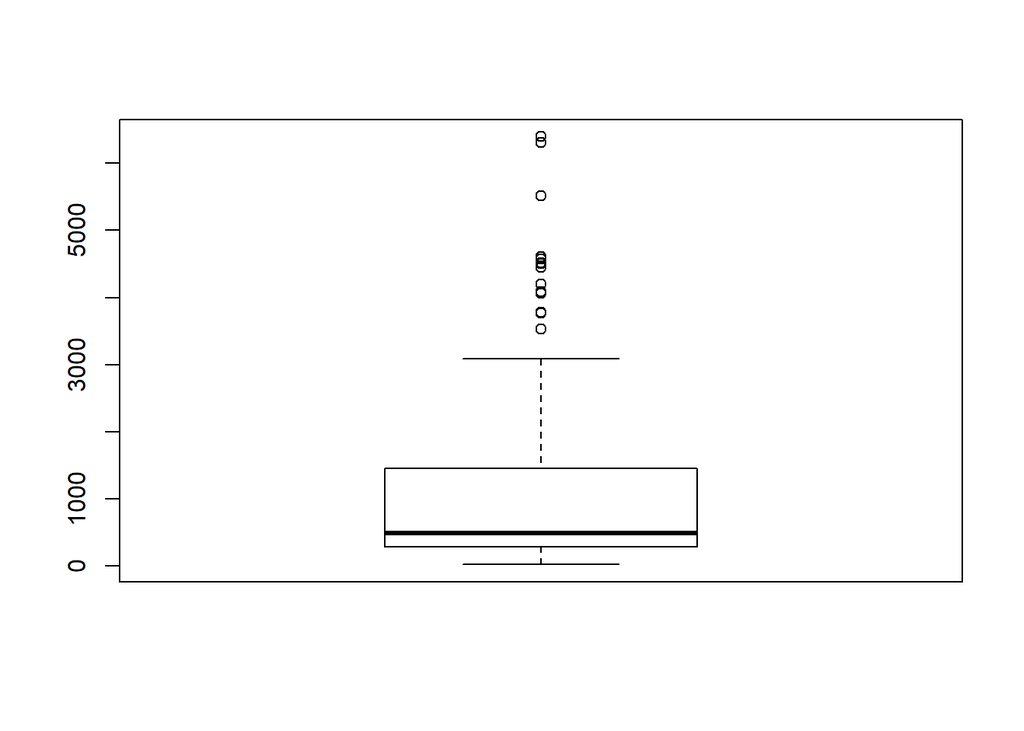

```r
boxplot(housing_train$distance_MRT)
```

```r
housing_train$MRT_group <-
  ifelse(housing_train$distance_MRT <= 100, '100s',
    ifelse(housing_train$distance_MRT <= 200, '200s',
       ifelse(housing_train$distance_MRT <= 300, '300s',
          ifelse(housing_train$distance_MRT <= 400, '400s',
             ifelse(housing_train$distance_MRT <= 500, '500s',
                ifelse(housing_train$distance_MRT <= 600, '600s',
                   ifelse(housing_train$distance_MRT <= 700, '700s',
                      ifelse(housing_train$distance_MRT <= 800, '800s',
                         ifelse(housing_train$distance_MRT <= 900, '900s',
                            ifelse(housing_train$distance_MRT <= 1000, '1000s', 'other'))))))))))

housing_test$MRT_group <-
  ifelse(housing_test$distance_MRT <= 100, '100s',
    ifelse(housing_test$distance_MRT <= 200, '200s',
       ifelse(housing_test$distance_MRT <= 300, '300s',
          ifelse(housing_test$distance_MRT <= 400, '400s',
             ifelse(housing_test$distance_MRT <= 500, '500s',
                ifelse(housing_test$distance_MRT <= 600, '600s',
                   ifelse(housing_test$distance_MRT <= 700, '700s',
                      ifelse(housing_test$distance_MRT <= 800, '800s',
                         ifelse(housing_test$distance_MRT <= 900, '900s',
                            ifelse(housing_test$distance_MRT <= 1000, '1000s', 'other'))))))))))

head(housing_train, 5)
```

```
##   year   month  age distance_MRT number_store latitude   degree price MRT_group
## 1 2012 10month 34.7     482.7581            5 24.97433 121.5386  41.1      500s
## 2 2012  9month 16.0    4066.5870            0 24.94297 121.5034  11.6     other
## 3 2012  8month  1.1     329.9747            5 24.98254 121.5439  51.8      400s
## 4 2012 12month 22.8     707.9067            2 24.98100 121.5471  36.6      800s
## 5 2012 10month 31.7    1160.6320            0 24.94968 121.5301  13.7     other
```

```r
head(housing_test, 5)
```

```
##   year   month  age distance_MRT number_store latitude   degree MRT_group
## 1 2012  8month  7.1    2175.0300            3 24.96305 121.5125     other
## 2 2012 11month 13.0     492.2313            5 24.96515 121.5374      500s
## 3 2012 11month 14.7    1360.1390            1 24.95204 121.5484     other
## 4 2012 12month 39.6     480.6977            4 24.97353 121.5388      500s
## 5 2013  1month 29.3    1487.8680            2 24.97542 121.5173     other
```

한편, 새로운 변수를 추가하기 위해 각각의 변수들을 살펴보던 중, 유의미할 것으로 생각되는 distance_MRT 변수를 박스플랏으로 확인합니다.

그리고 1000 보다 작은 수들은 100 단위로 묶어서 그룹화를 시켜주고, 이 과정을 train과 test 데이터에 모두 수행합니다.

```r
model <- lm(price~., data = housing_train)
step(model, direction = 'both')
```

```
## Start:  AIC=1260.11
## price ~ year + month + age + distance_MRT + number_store + latitude +
##     degree + MRT_group
##
##
## Step:  AIC=1260.11
## price ~ month + age + distance_MRT + number_store + latitude +
##     degree + MRT_group
##
##                Df Sum of Sq   RSS    AIC
## - distance_MRT  1       2.3 14628 1258.2
## <none>                      14625 1260.1
## - degree        1     163.0 14788 1261.6
## - number_store  1     380.1 15006 1266.2
## - month        11    1477.4 16103 1268.3
## - latitude      1    1239.1 15864 1283.7
## - age           1    1649.8 16275 1291.7
## - MRT_group    10    5772.9 20398 1344.6
##
## Step:  AIC=1258.16
## price ~ month + age + number_store + latitude + degree + MRT_group
##
##                Df Sum of Sq   RSS    AIC
## <none>                      14628 1258.2
## + distance_MRT  1       2.3 14625 1260.1
## - degree        1     233.9 14862 1261.1
## - number_store  1     378.7 15006 1264.2
## - month        11    1482.5 16110 1266.5
## - latitude      1    1390.9 16018 1284.7
## - age           1    1652.8 16280 1289.8
## - MRT_group    10    7635.3 22263 1370.0
```

```
##
## Call:
## lm(formula = price ~ month + age + number_store + latitude +
##     degree + MRT_group, data = housing_train)
##
## Coefficients:
##    (Intercept)    month11month    month12month     month1month     month2month
##     -1.509e+04      -9.738e-01      -2.154e-01       2.009e+00       1.384e+00
##    month3month     month4month     month5month     month6month     month7month
##      2.153e+00       1.480e+00       1.783e+00       5.277e+00       7.053e+00
##    month8month     month9month             age    number_store        latitude
##      1.256e-01      -5.911e-01      -2.278e-01       5.708e-01       2.200e+02
##         degree   MRT_group100s   MRT_group200s   MRT_group300s   MRT_group400s
##      7.923e+01       1.354e+01       1.080e+01       1.295e+01       5.755e+00
##  MRT_group500s   MRT_group600s   MRT_group700s   MRT_group800s   MRT_group900s
##      4.841e+00       6.089e+00       6.265e+00       5.275e+00      -1.187e+00
## MRT_groupother
##     -5.590e+00
```

가장 먼저는 전체 변수를 기준으로 model을 만들고, AIC가 가장 좋은 값을 만드는 변수를 추려주는 stepwise 함수를 통해 변수들을 추려줍니다.

```r
model1 <- lm(formula = price ~ month + age + I(number_store^2)*distance_MRT + I(latitude^2) +
               I(degree^2) + degree*latitude + MRT_group + I(distance_MRT^2)*age, data = housing_train)

housing_test$pred <- predict(model1, newdata = housing_test)
pred_housing_test <- housing_test$pred
save(pred_housing_test, file = 'st21500268.Rdata')
```

위에서 수행했던 step 함수를 기반으로 최적의 변수들을 기반으로 interaction 과정을 수행합니다.

또한 경험적으로 반복해서 상호검증을 수행한 결과, RMSE는 9.377, R2 값은 0.607이 되는 것을 볼 수 있었습니다.

```r
str(shopping_train)
```

```
## 'data.frame':    10000 obs. of  18 variables:
##  $ Administrative         : int  0 0 0 0 0 0 1 0 0 0 ...
##  $ Administrative_Duration: num  0 0 0 0 0 0 0 0 0 0 ...
##  $ Informational          : int  0 0 0 0 0 0 0 0 0 0 ...
##  $ Informational_Duration : num  0 0 0 0 0 0 0 0 0 0 ...
##  $ ProductRelated         : int  1 2 1 2 10 1 0 2 3 16 ...
##  $ ProductRelated_Duration: num  0 64 0 2.67 627.5 ...
##  $ BounceRates            : num  0.2 0 0.2 0.05 0.02 ...
##  $ ExitRates              : num  0.2 0.1 0.2 0.14 0.05 ...
##  $ PageValues             : num  0 0 0 0 0 0 0 0 0 0 ...
##  $ SpecialDay             : num  0 0 0 0 0 0.4 0 0.8 0 0.4 ...
##  $ Month                  : Factor w/ 10 levels "Aug","Dec","Feb",..: 3 3 3 3 3 3 3 3 3 3 ...
##  $ OperatingSystems       : int  1 2 4 3 3 2 1 2 1 1 ...
##  $ Browser                : int  1 2 1 2 3 4 2 2 1 1 ...
##  $ Region                 : int  1 1 9 2 1 3 1 2 3 4 ...
##  $ TrafficType            : int  1 2 3 4 4 3 5 3 3 3 ...
##  $ VisitorType            : Factor w/ 3 levels "New_Visitor",..: 3 3 3 3 3 3 3 3 3 3 ...
##  $ Weekend                : logi  FALSE FALSE FALSE FALSE TRUE FALSE ...
##  $ Revenue                : logi  FALSE FALSE FALSE FALSE FALSE FALSE ...
```

가장 먼저 전처리 과정을 수행하기 위해 str 함수로 전체 변수의 형태를 확인합니다.

전반적으로 변수의 type은 잘 설정이 되어 있는 것 같아서 전처리 과정 없이 바로 model을 만듭니다.

```r
model2 <- glm(Revenue ~ ., data = shopping_train, family = binomial(link = 'logit'))
step(model2, direction = 'both')
```

```
## Start:  AIC=5778.87
## Revenue ~ Administrative + Administrative_Duration + Informational +
##     Informational_Duration + ProductRelated + ProductRelated_Duration +
##     BounceRates + ExitRates + PageValues + SpecialDay + Month +
##     OperatingSystems + Browser + Region + TrafficType + VisitorType +
##     Weekend
```

```
##                           Df Deviance    AIC
## - TrafficType              1   5724.9 5776.9
## - Administrative           1   5725.0 5777.0
## - Region                   1   5725.0 5777.0
## - Administrative_Duration  1   5725.1 5777.1
## - Informational_Duration   1   5725.1 5777.1
## - SpecialDay               1   5725.4 5777.4
## - Weekend                  1   5726.4 5778.4
## <none>                         5724.9 5778.9
## - ProductRelated           1   5727.0 5779.0
## - Browser                  1   5727.3 5779.3
## - BounceRates              1   5727.4 5779.4
## - OperatingSystems         1   5727.4 5779.4
## - ProductRelated_Duration  1   5729.1 5781.1
## - Informational            1   5729.7 5781.7
## - VisitorType              2   5734.6 5784.6
## - ExitRates                1   5756.0 5808.0
## - Month                    9   5904.4 5940.4
## - PageValues               1   7507.5 7559.5
##
## Step:  AIC=5776.88
## Revenue ~ Administrative + Administrative_Duration + Informational +
##     Informational_Duration + ProductRelated + ProductRelated_Duration +
##     BounceRates + ExitRates + PageValues + SpecialDay + Month +
##     OperatingSystems + Browser + Region + VisitorType + Weekend
```

```
##                           Df Deviance    AIC
## - Administrative           1   5725.0 5775.0
## - Region                   1   5725.0 5775.0
## - Administrative_Duration  1   5725.1 5775.1
## - Informational_Duration   1   5725.1 5775.1
## - SpecialDay               1   5725.4 5775.4
## - Weekend                  1   5726.4 5776.4
## <none>                         5724.9 5776.9
## - ProductRelated           1   5727.0 5777.0
## - Browser                  1   5727.3 5777.3
## - BounceRates              1   5727.4 5777.4
## - OperatingSystems         1   5727.4 5777.4
## + TrafficType              1   5724.9 5778.9
## - ProductRelated_Duration  1   5729.1 5779.1
## - Informational            1   5729.7 5779.7
## - VisitorType              2   5734.6 5782.6
## - ExitRates                1   5756.0 5806.0
## - Month                    9   5905.7 5939.7
## - PageValues               1   7507.6 7557.6
##
## Step:  AIC=5774.97
## Revenue ~ Administrative_Duration + Informational + Informational_Duration +
##     ProductRelated + ProductRelated_Duration + BounceRates +
##     ExitRates + PageValues + SpecialDay + Month + OperatingSystems +
##     Browser + Region + VisitorType + Weekend
```

```
##                           Df Deviance    AIC
## - Region                   1   5725.1 5773.1
## - Administrative_Duration  1   5725.1 5773.1
## - Informational_Duration   1   5725.2 5773.2
## - SpecialDay               1   5725.6 5773.6
## - Weekend                  1   5726.5 5774.5
## <none>                         5725.0 5775.0
## - Browser                  1   5727.4 5775.4
## - BounceRates              1   5727.4 5775.4
## - OperatingSystems         1   5727.5 5775.5
## - ProductRelated           1   5727.5 5775.5
## + Administrative           1   5724.9 5776.9
## + TrafficType              1   5725.0 5777.0
## - ProductRelated_Duration  1   5729.1 5777.1
## - Informational            1   5730.2 5778.2
## - VisitorType              2   5734.7 5780.7
## - ExitRates                1   5757.0 5805.0
## - Month                    9   5905.7 5937.7
## - PageValues               1   7511.1 7559.1
##
## Step:  AIC=5773.09
## Revenue ~ Administrative_Duration + Informational + Informational_Duration +
##     ProductRelated + ProductRelated_Duration + BounceRates +
##     ExitRates + PageValues + SpecialDay + Month + OperatingSystems +
##     Browser + VisitorType + Weekend
```

```
##                           Df Deviance    AIC
## - Administrative_Duration  1   5725.2 5771.2
## - Informational_Duration   1   5725.3 5771.3
## - SpecialDay               1   5725.7 5771.7
## - Weekend                  1   5726.6 5772.6
## <none>                         5725.1 5773.1
## - Browser                  1   5727.5 5773.5
## - BounceRates              1   5727.5 5773.5
## - OperatingSystems         1   5727.6 5773.6
## - ProductRelated           1   5727.6 5773.6
## + Region                   1   5725.0 5775.0
## + Administrative           1   5725.0 5775.0
## + TrafficType              1   5725.1 5775.1
## - ProductRelated_Duration  1   5729.3 5775.3
## - Informational            1   5730.3 5776.3
## - VisitorType              2   5734.8 5778.8
## - ExitRates                1   5757.1 5803.1
## - Month                    9   5906.1 5936.1
## - PageValues               1   7511.9 7557.9
##
## Step:  AIC=5771.24
## Revenue ~ Informational + Informational_Duration + ProductRelated +
##     ProductRelated_Duration + BounceRates + ExitRates + PageValues +
##     SpecialDay + Month + OperatingSystems + Browser + VisitorType +
##     Weekend
```

```
##                           Df Deviance    AIC
## - Informational_Duration   1   5725.5 5769.5
## - SpecialDay               1   5725.8 5769.8
## - Weekend                  1   5726.8 5770.8
## <none>                         5725.2 5771.2
## - Browser                  1   5727.6 5771.6
## - OperatingSystems         1   5727.7 5771.7
## - BounceRates              1   5727.8 5771.8
## - ProductRelated           1   5727.9 5771.9
## + Administrative_Duration  1   5725.1 5773.1
## + Region                   1   5725.1 5773.1
## + TrafficType              1   5725.2 5773.2
## + Administrative           1   5725.2 5773.2
## - ProductRelated_Duration  1   5729.3 5773.3
## - Informational            1   5730.3 5774.3
## - VisitorType              2   5734.9 5776.9
## - ExitRates                1   5757.1 5801.1
## - Month                    9   5906.5 5934.5
## - PageValues               1   7512.0 7556.0
##
## Step:  AIC=5769.5
## Revenue ~ Informational + ProductRelated + ProductRelated_Duration +
##     BounceRates + ExitRates + PageValues + SpecialDay + Month +
##     OperatingSystems + Browser + VisitorType + Weekend
```

```
##                           Df Deviance    AIC
## - SpecialDay               1   5726.1 5768.1
## - Weekend                  1   5727.0 5769.0
## <none>                         5725.5 5769.5
## - Browser                  1   5727.9 5769.9
## - OperatingSystems         1   5728.0 5770.0
## - BounceRates              1   5728.0 5770.0
## - ProductRelated           1   5728.4 5770.4
## + Informational_Duration   1   5725.2 5771.2
## - ProductRelated_Duration  1   5729.3 5771.3
## + Administrative_Duration  1   5725.3 5771.3
## + Region                   1   5725.4 5771.4
## + TrafficType              1   5725.5 5771.5
## + Administrative           1   5725.5 5771.5
## - Informational            1   5731.0 5773.0
## - VisitorType              2   5735.2 5775.2
## - ExitRates                1   5757.4 5799.4
## - Month                    9   5906.9 5932.9
## - PageValues               1   7512.1 7554.1
##
## Step:  AIC=5768.07
## Revenue ~ Informational + ProductRelated + ProductRelated_Duration +
##     BounceRates + ExitRates + PageValues + Month + OperatingSystems +
##     Browser + VisitorType + Weekend
```

```
##                           Df Deviance    AIC
## - Weekend                  1   5727.6 5767.6
## <none>                         5726.1 5768.1
## - Browser                  1   5728.4 5768.4
## - OperatingSystems         1   5728.6 5768.6
## - BounceRates              1   5728.6 5768.6
## - ProductRelated           1   5728.9 5768.9
## + SpecialDay               1   5725.5 5769.5
## + Informational_Duration   1   5725.8 5769.8
## + Administrative_Duration  1   5725.9 5769.9
## - ProductRelated_Duration  1   5729.9 5769.9
## + Region                   1   5726.0 5770.0
## + TrafficType              1   5726.1 5770.1
## + Administrative           1   5726.1 5770.1
## - Informational            1   5731.7 5771.7
## - VisitorType              2   5735.8 5773.8
## - ExitRates                1   5758.4 5798.4
## - Month                    9   5924.3 5948.3
## - PageValues               1   7522.1 7562.1
##
## Step:  AIC=5767.57
## Revenue ~ Informational + ProductRelated + ProductRelated_Duration +
##     BounceRates + ExitRates + PageValues + Month + OperatingSystems +
##     Browser + VisitorType
```

```
##                           Df Deviance    AIC
## <none>                         5727.6 5767.6
## - Browser                  1   5729.9 5767.9
## - OperatingSystems         1   5730.0 5768.0
## + Weekend                  1   5726.1 5768.1
## - BounceRates              1   5730.1 5768.1
## - ProductRelated           1   5730.4 5768.4
## + SpecialDay               1   5727.0 5769.0
## - ProductRelated_Duration  1   5731.3 5769.3
## + Informational_Duration   1   5727.3 5769.3
## + Administrative_Duration  1   5727.4 5769.4
## + Region                   1   5727.5 5769.5
## + TrafficType              1   5727.6 5769.6
## + Administrative           1   5727.6 5769.6
## - Informational            1   5733.4 5771.4
## - VisitorType              2   5737.6 5773.6
## - ExitRates                1   5760.4 5798.4
## - Month                    9   5928.0 5950.0
## - PageValues               1   7522.6 7560.6
```

```
##
## Call:  glm(formula = Revenue ~ Informational + ProductRelated + ProductRelated_Duration +
##     BounceRates + ExitRates + PageValues + Month + OperatingSystems +
##     Browser + VisitorType, family = binomial(link = "logit"),
##     data = shopping_train)
##
## Coefficients:
##                  (Intercept)                 Informational
##                   -1.697e+00                     5.910e-02
##               ProductRelated       ProductRelated_Duration
##                    2.157e-03                     5.181e-05
##                  BounceRates                     ExitRates
##                   -5.642e+00                    -1.395e+01
##                   PageValues                      MonthDec
##                    8.603e-02                    -5.550e-01
##                     MonthFeb                      MonthJul
##                   -2.769e+00                     1.040e-01
##                    MonthJune                      MonthMar
##                   -6.351e-01                    -4.189e-01
##                     MonthMay                      MonthNov
##                   -5.743e-01                     5.399e-01
##                     MonthOct                      MonthSep
##                   -1.817e-01                     3.705e-02
##             OperatingSystems                       Browser
##                   -6.633e-02                     3.257e-02
##             VisitorTypeOther  VisitorTypeReturning_Visitor
##                   -4.155e-01                    -3.099e-01
##
## Degrees of Freedom: 9999 Total (i.e. Null);  9980 Residual
## Null Deviance:       8612
## Residual Deviance: 5728  AIC: 5768
```

```r
model3 <- glm(formula = Revenue ~ . + ProductRelated*SpecialDay +
                ProductRelated_Duration + I(BounceRates^2)*Month +
                I(ExitRates^2)*I(PageValues^2)*SpecialDay +
                I(PageValues^2)*VisitorType + Month*VisitorType +
                OperatingSystems*I(BounceRates^2)*Browser +
                Browser*I(TrafficType^2) +
                VisitorType*Weekend*SpecialDay +
                I(Administrative^2)*I(Administrative_Duration^2) +
                I(Informational^2)*I(Informational_Duration^2) +
                I(Administrative^2) + I(Informational^2) +
                I(Browser^2) + I(Region^2) +
                PageValues*SpecialDay*ProductRelated +
                OperatingSystems*I(Browser^2), family = binomial(link = "logit"), data = shopping_train)
```

그 변수들을 기준으로 경험적인 상호교차 검증 과정을 통해 model을 만들어줍니다.

```r
shopping_train$prob <- predict(model3, shopping_train, type = 'response')
shopping_train$pred <- ifelse(shopping_train$prob >= 0.17, TRUE, FALSE)
cf.table <- table(Actual = shopping_train$Revenue, Predict = shopping_train$pred)
((cf.table[1, 1]/sum(cf.table[1, ])) + (cf.table[2, 2]/sum(cf.table[2, ]))) / 2
```

```
## [1] 0.8210782
```

위에서 만든 모델을 기반으로 확률값과 예측값을 새롭게 만들어줍니다.

예측값을 만들때는 balanced accuracy 값을 위해서 threshold를 0.01 단위로 조정하면서 최적의 값을 찾았습니다.

```r
shopping_test$prob <- predict(model3, shopping_test, type = 'response')
shopping_test$pred <- ifelse(shopping_test$prob >= 0.17, TRUE, FALSE)

prob_shopping_test <- shopping_test$prob
pred_shopping_test <- shopping_test$pred
save(pred_housing_test, prob_shopping_test, pred_shopping_test, file = 'st21500268.Rdata')
```

이 과정을 마지막으로 test 데이터에 적용하고, 동일한 threshold로 확률값과 예측값을 만들었습니다.

그리고 지금까지 했던 Classification, Regression 문제의 3개의 vector를 하나의 Rdata 파일로 만들어서 저장합니다.